```python
from google.colab import drive
drive.mount('/content/drive')
```

# **Part A - 30 Marks**

**DOMAIN** : Electronics and Telecommunication

**CONTEXT:** A communications equipment manufacturing company has a product which is responsible for emitting informative signals.Company wants to build a machine learning model which can help the company to predict the equipment’s signal quality using various parameters.

**DATA DESCRIPTION:** The data set contains information on various signal tests performed:

1. Parameters: Various measurable signal parameters.
2. Signal_Quality: Final signal strength or quality

**PROJECT OBJECTIVE:** To build a classifier which can use the given parameters to determine the signal strength or qualit

## **Steps and tasks:**

### **1. Data import and Understanding**

**A. Read the ‘Signals.csv’ as DataFrame and import required libraries.**

```python
#Importing variou libraries
import numpy as np
import pandas as pd
import seaborn as sns
import matplotlib.pyplot as plt
from sklearn.model_selection import train_test_split
from sklearn.preprocessing import StandardScaler
from sklearn.preprocessing import LabelEncoder
```

```python
signal_df=pd.read_csv("/content/drive/MyDrive/AI-ML/ANN_Project/Signal.csv")
```

```python
signal_df.head()
```

|  | Parameter 1 | Parameter 2 | Parameter 3 | Parameter 4 | Parameter 5 | Parameter 6 | Parameter 7 | Parameter 8 | Parameter 9 | Parameter 10 | Parameter 11 | Signal_Strength |
| --- | --- | --- | --- | --- | --- | --- | --- | --- | --- | --- | --- | --- |
| 0 | 7.4 | 0.70 | 0.00 | 1.9 | 0.076 | 11.0 | 34.0 | 0.9978 | 3.51 | 0.56 | 9.4 | 5 |
| 1 | 7.8 | 0.88 | 0.00 | 2.6 | 0.098 | 25.0 | 67.0 | 0.9968 | 3.20 | 0.68 | 9.8 | 5 |
| 2 | 7.8 | 0.76 | 0.04 | 2.3 | 0.092 | 15.0 | 54.0 | 0.9970 | 3.26 | 0.65 | 9.8 | 5 |
| 3 | 11.2 | 0.28 | 0.56 | 1.9 | 0.075 | 17.0 | 60.0 | 0.9980 | 3.16 | 0.58 | 9.8 | 6 |
| 4 | 7.4 | 0.70 | 0.00 | 1.9 | 0.076 | 11.0 | 34.0 | 0.9978 | 3.51 | 0.56 | 9.4 | 5 |

```python
signal_df.shape
```

```
(1599, 12)
```

```python
signal_df.info()
```

```
<class 'pandas.core.frame.DataFrame'>
RangeIndex: 1599 entries, 0 to 1598
Data columns (total 12 columns):
 #   Column           Non-Null Count  Dtype
---  ------           --------------  -----
 0   Parameter 1      1599 non-null   float64
 1   Parameter 2      1599 non-null   float64
 2   Parameter 3      1599 non-null   float64
 3   Parameter 4      1599 non-null   float64
 4   Parameter 5      1599 non-null   float64
 5   Parameter 6      1599 non-null   float64
 6   Parameter 7      1599 non-null   float64
 7   Parameter 8      1599 non-null   float64
 8   Parameter 9      1599 non-null   float64
 9   Parameter 10     1599 non-null   float64
 10  Parameter 11     1599 non-null   float64
 11  Signal_Strength  1599 non-null   int64
dtypes: float64(11), int64(1)
memory usage: 150.0 KB
```

**B. Check for missing values and print percentage for each attribute.**

```python
print('Attribute-wise percentage of missing values.\n',(signal_df.isnull().sum()/len(signal_df) * 100 ))
```

```
Attribute-wise percentage of missing values.
 Parameter 1        0.0
Parameter 2        0.0
Parameter 3        0.0
Parameter 4        0.0
Parameter 5        0.0
Parameter 6        0.0
Parameter 7        0.0
Parameter 8        0.0
Parameter 9        0.0
Parameter 10       0.0
Parameter 11       0.0
Signal_Strength    0.0
dtype: float64
```

**C. Check for presence of duplicate records in the dataset and impute with appropriate method.**

```python
print('Number of dupliacte records in the data',signal_df.duplicated().sum())
signal_df[signal_df.duplicated()]
```

```
Number of dupliacte records in the data 240
```

|  | Parameter 1 | Parameter 2 | Parameter 3 | Parameter 4 | Parameter 5 | Parameter 6 | Parameter 7 | Parameter 8 | Parameter 9 | Parameter 10 | Parameter 11 | Signal_Strength |
| --- | --- | --- | --- | --- | --- | --- | --- | --- | --- | --- | --- | --- |
| 4 | 7.4 | 0.700 | 0.00 | 1.90 | 0.076 | 11.0 | 34.0 | 0.99780 | 3.51 | 0.56 | 9.4 | 5 |
| 11 | 7.5 | 0.500 | 0.36 | 6.10 | 0.071 | 17.0 | 102.0 | 0.99780 | 3.35 | 0.80 | 10.5 | 5 |
| 27 | 7.9 | 0.430 | 0.21 | 1.60 | 0.106 | 10.0 | 37.0 | 0.99660 | 3.17 | 0.91 | 9.5 | 5 |
| 40 | 7.3 | 0.450 | 0.36 | 5.90 | 0.074 | 12.0 | 87.0 | 0.99780 | 3.33 | 0.83 | 10.5 | 5 |
| 65 | 7.2 | 0.725 | 0.05 | 4.65 | 0.086 | 4.0 | 11.0 | 0.99620 | 3.41 | 0.39 | 10.9 | 5 |
| ... | ... | ... | ... | ... | ... | ... | ... | ... | ... | ... | ... | ... |
| 1563 | 7.2 | 0.695 | 0.13 | 2.00 | 0.076 | 12.0 | 20.0 | 0.99546 | 3.29 | 0.54 | 10.1 | 5 |
| 1564 | 7.2 | 0.695 | 0.13 | 2.00 | 0.076 | 12.0 | 20.0 | 0.99546 | 3.29 | 0.54 | 10.1 | 5 |
| 1567 | 7.2 | 0.695 | 0.13 | 2.00 | 0.076 | 12.0 | 20.0 | 0.99546 | 3.29 | 0.54 | 10.1 | 5 |
| 1581 | 6.2 | 0.560 | 0.09 | 1.70 | 0.053 | 24.0 | 32.0 | 0.99402 | 3.54 | 0.60 | 11.3 | 5 |
| 1596 | 6.3 | 0.510 | 0.13 | 2.30 | 0.076 | 29.0 | 40.0 | 0.99574 | 3.42 | 0.75 | 11.0 | 6 |

240 rows × 12 columns

```python
#Removing the duplicate Records
df = signal_df.drop_duplicates(keep='first', inplace=False)
print('Number of dupliacte records in the data after Imputation',df.duplicated().sum())
print('Shape of the imputed data',df.shape)
```

```
Number of dupliacte records in the data after Imputation 0
Shape of the imputed data (1359, 12)
```

**D. Visualise distribution of the target variable.**

```python
df['Signal_Strength'].unique()
```

```
array([5, 6, 7, 4, 8, 3])
```

```python
df['Signal_Strength'].value_counts()
```

```
5    577
6    535
7    167
4     53
8     17
3     10
Name: Signal_Strength, dtype: int64
```

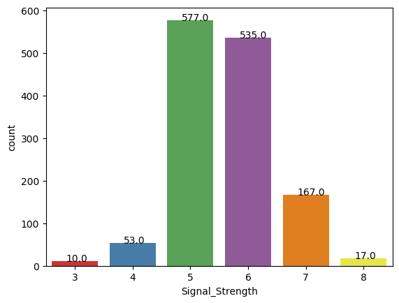

```python
ax =sns.countplot(data= df, x='Signal_Strength',palette = "Set1")
for p in ax.patches:
   ax.annotate('{:.1f}'.format(p.get_height()), (p.get_x()+0.25, p.get_height()+0.01))
plt.show()
```

**Observation:**

- There are 6 unique values in "Signal_Strenght" column.
- Signal_Strength '5' and '6' are top 2 most common values.
- Signal_Strength '3' least common values.

**E. Share insights from the initial data analysis. (at least 2).**

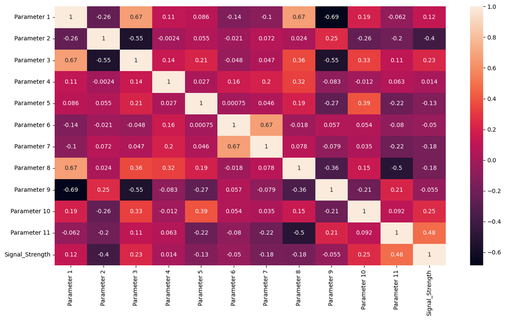

```python
corr = df.corr()
plt.figure(figsize=(15,8))
sns.heatmap(corr, xticklabels=corr.columns.values, yticklabels=corr.columns.values, annot = True)
plt.show()
```

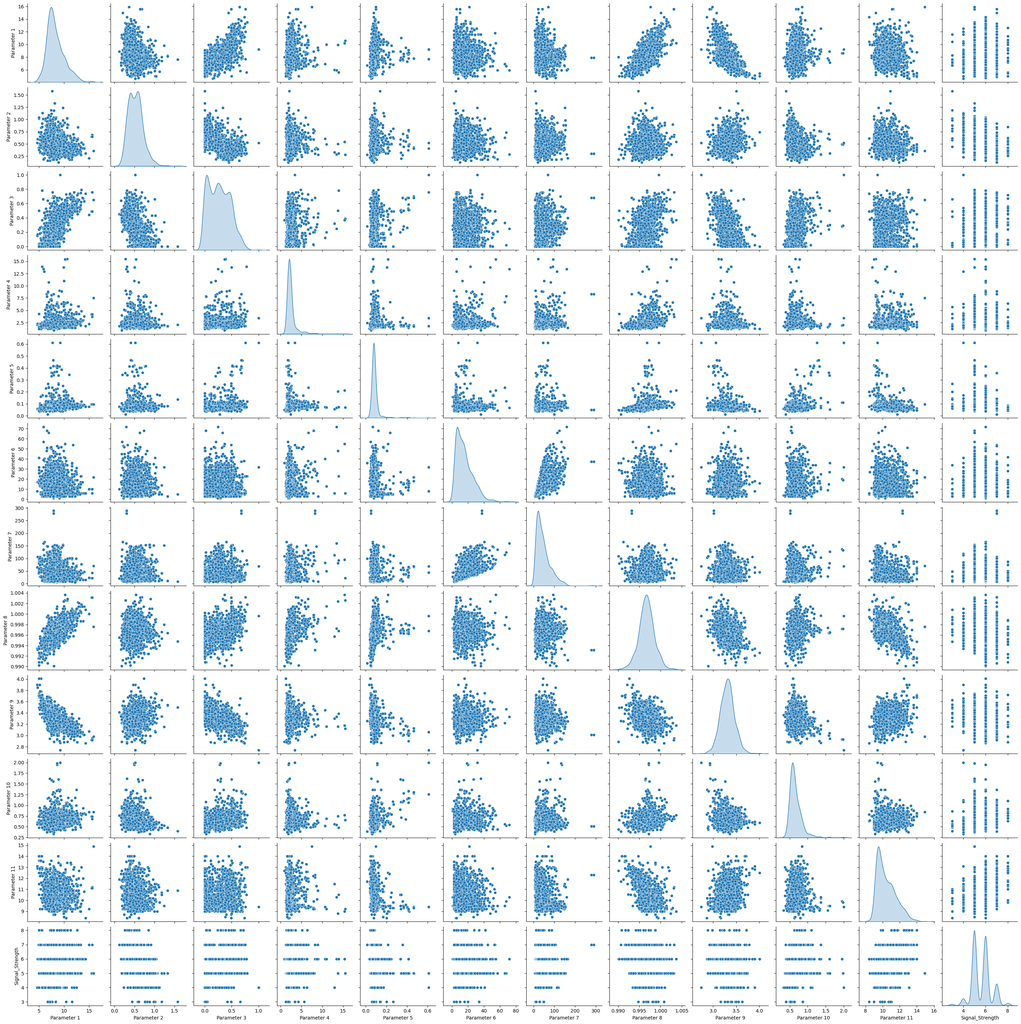

```python
sns.pairplot(df,diag_kind='kde')
plt.figure(figsize=(5,5))
plt.show()
```

**Observations**

1. From the heat map we can conculde that, Parameter (1,3), Parameter (1,8) and Parameter (6,7) are highly corelated.
2. From the Pair plot we can observe that most of the columns are highl skewed data.

### **2. Data preprocessing**

**A. Split the data into X & Y**

```python
X = df.drop('Signal_Strength', axis=1)
Y = df['Signal_Strength']
```

**B. Split the data into train & test with 70:30 proportion.**

```python
X_Train, X_Test, Y_Train, Y_Test = train_test_split(X, Y, train_size=0.7, random_state=12)
```

**C.Print shape of all the 4 variables and verify if train and test data is in sync**

```python
print("Shape of X_Train:", X_Train.shape)
print("Shape of X_Test:", X_Test.shape)
print("Shape of Y_Train:", Y_Train.shape)
print("Shape of Y_Test:", Y_Test.shape)
```

```
Shape of X_Train: (951, 11)
Shape of X_Test: (408, 11)
Shape of Y_Train: (951,)
Shape of Y_Test: (408,)
```

**D. Normalise the train and test data with appropriate method.**

```python
# Scaling training data
X_Train_S = StandardScaler().fit_transform(X_Train)

# Scaling testing data
X_Test_S = StandardScaler().fit_transform(X_Test)
```

```python
print(X_Train_S.shape)
print(X_Test_S.shape)
print(Y_Train.shape)
print(Y_Test.shape)
```

```
(951, 11)
(408, 11)
(951,)
(408,)
```

**E. Transform Labels into format acceptable by Neural Network**

```python
import tensorflow as tf
from tensorflow.keras.utils import to_categorical
y_train = to_categorical(Y_Train)
y_test = to_categorical(Y_Test)
```

```python
print(X_Train_S.shape)
print(X_Test_S.shape)
print(y_train.shape)
print(y_test.shape)
```

```
(951, 11)
(408, 11)
(951, 9)
(408, 9)
```

## **3. Model Training & Evaluation using Neural Network**

**A. Design a Neural Network to train a classifier.**

```python
from keras.models import Sequential
from keras.layers import Dense, Activation, LeakyReLU
from keras import optimizers
```

```python
NN_model_Regressor = Sequential()

# The Input Layer :
NN_model_Regressor.add(Dense(128, kernel_initializer='normal',input_dim=X_Train.shape[1], activation='relu'))

# The Hidden Layers :
NN_model_Regressor.add(Dense(64, kernel_initializer='normal', activation='relu'))
NN_model_Regressor.add(Dense(32, kernel_initializer='normal'))
NN_model_Regressor.add(LeakyReLU(alpha=0.1))
NN_model_Regressor.add(Dense(16, kernel_initializer='normal'))
NN_model_Regressor.add(LeakyReLU(alpha=0.1))


# The Output Layer :
NN_model_Regressor.add(Dense(1, kernel_initializer='normal'))  # except softmax
NN_model_Regressor.add(LeakyReLU(alpha=0.1))

# Compile the network :
NN_model_Regressor.compile(loss='mean_absolute_error',optimizer='adam', metrics=['accuracy'])
NN_model_Regressor.summary()
```

```
Model: "sequential"
_________________________________________________________________
 Layer (type)                Output Shape              Param #
=================================================================
 dense (Dense)               (None, 128)               1536

 dense_1 (Dense)             (None, 64)                8256

 dense_2 (Dense)             (None, 32)                2080

 leaky_re_lu (LeakyReLU)     (None, 32)                0

 dense_3 (Dense)             (None, 16)                528

 leaky_re_lu_1 (LeakyReLU)   (None, 16)                0

 dense_4 (Dense)             (None, 1)                 17

 leaky_re_lu_2 (LeakyReLU)   (None, 1)                 0

=================================================================
Total params: 12417 (48.50 KB)
Trainable params: 12417 (48.50 KB)
Non-trainable params: 0 (0.00 Byte)
_________________________________________________________________
```

**B. Train the classifier using previously designed Architecture**

```python
EPOCH=400
Network_Regressor=NN_model_Regressor.fit(X_Train_S, Y_Train, validation_data=(X_Test_S,Y_Test), epochs=EPOCH, batch_size=200)
```

### **C. Plot 2 separate visuals.**

*i. Training Loss and Validation Loss*

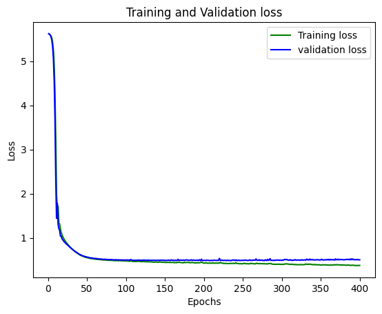

```python
loss_train = Network_Regressor.history['loss']
loss_val = Network_Regressor.history['val_loss']
epochs = range(1, EPOCH+1)
plt.plot(epochs, loss_train, 'g', label='Training loss')
plt.plot(epochs, loss_val, 'b', label='validation loss')
plt.title('Training and Validation loss')
plt.xlabel('Epochs')
plt.ylabel('Loss')
plt.legend()
plt.show()
```

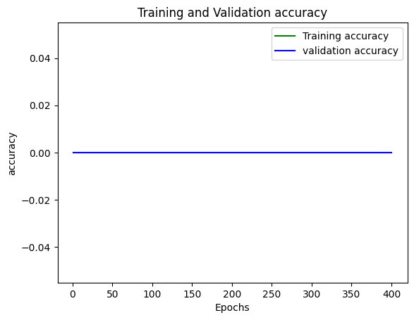

```python
Acc_train = Network_Regressor.history['accuracy']
Acc_val = Network_Regressor.history['val_accuracy']
epochs = range(1, EPOCH+1)
plt.plot(epochs, Acc_train, 'g', label='Training accuracy')
plt.plot(epochs, Acc_val, 'b', label='validation accuracy')
plt.title('Training and Validation accuracy')
plt.xlabel('Epochs')
plt.ylabel('accuracy')
plt.legend()
plt.show()
```

**D. Design new architecture/update existing architecture in attempt to improve the performance of the model.**

```python
from sklearn.datasets import make_classification
```

```python
X, Y = make_classification(n_samples=1000, n_features=5, n_informative=2,n_redundant=3, n_repeated=0, n_classes=2,shuffle=True, random_state=2020)
```

```python
X_Train,X_Test,Y_Train,Y_Test=train_test_split(X, Y, train_size=0.7, random_state=12)
```

```python
# Scaling training data
X_Train_S = StandardScaler().fit_transform(X_Train)

# Scaling testing data
X_Test_S = StandardScaler().fit_transform(X_Test)
```

```python
NN_model_Regressor = Sequential()

# The Input Layer :
NN_model_Regressor.add(Dense(128, kernel_initializer='normal',
                       input_dim=X_Train.shape[1], activation='relu'))

# The Hidden Layers :
NN_model_Regressor.add(
    Dense(64, kernel_initializer='normal', activation='relu'))  # sigmoid, tanh

NN_model_Regressor.add(Dense(32, kernel_initializer='normal'))
NN_model_Regressor.add(LeakyReLU(alpha=0.1))

NN_model_Regressor.add(Dense(16, kernel_initializer='normal'))
NN_model_Regressor.add(LeakyReLU(alpha=0.1))


# The Output Layer :
NN_model_Regressor.add(Dense(1, kernel_initializer='normal'))  # except softmax
NN_model_Regressor.add(LeakyReLU(alpha=0.1))

# Compile the network :
NN_model_Regressor.compile(loss='mean_absolute_error',
                           optimizer='adam', metrics=['accuracy'])
NN_model_Regressor.summary()
```

```
Model: "sequential_1"
_________________________________________________________________
 Layer (type)                Output Shape              Param #
=================================================================
 dense_5 (Dense)             (None, 128)               768

 dense_6 (Dense)             (None, 64)                8256

 dense_7 (Dense)             (None, 32)                2080

 leaky_re_lu_3 (LeakyReLU)   (None, 32)                0

 dense_8 (Dense)             (None, 16)                528

 leaky_re_lu_4 (LeakyReLU)   (None, 16)                0

 dense_9 (Dense)             (None, 1)                 17

 leaky_re_lu_5 (LeakyReLU)   (None, 1)                 0

=================================================================
Total params: 11649 (45.50 KB)
Trainable params: 11649 (45.50 KB)
Non-trainable params: 0 (0.00 Byte)
_________________________________________________________________
```

```python
EPOCH=400
Network_Regressor=NN_model_Regressor.fit(X_Train_S, Y_Train, validation_data=(X_Test_S,Y_Test), epochs=EPOCH, batch_size=200)
```

**E. Plot visuals as in Q3.C and share insights about difference observed in both the models.**

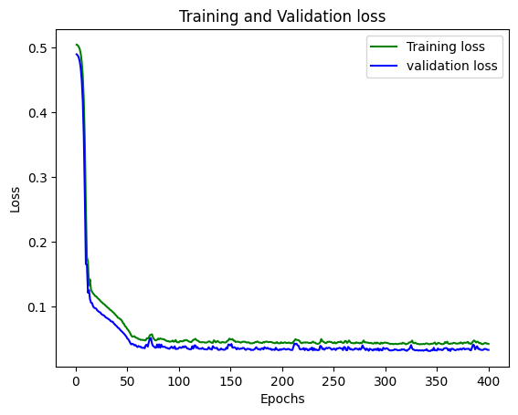

```python
loss_train = Network_Regressor.history['loss']
loss_val = Network_Regressor.history['val_loss']
epochs = range(1, EPOCH+1)
plt.plot(epochs, loss_train, 'g', label='Training loss')
plt.plot(epochs, loss_val, 'b', label='validation loss')
plt.title('Training and Validation loss')
plt.xlabel('Epochs')
plt.ylabel('Loss')
plt.legend()
plt.show()
```

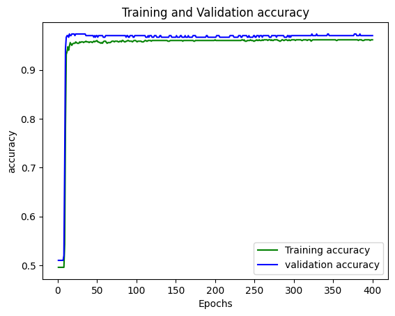

```python
Acc_train = Network_Regressor.history['accuracy']
Acc_val = Network_Regressor.history['val_accuracy']
epochs = range(1, EPOCH+1)
plt.plot(epochs, Acc_train, 'g', label='Training accuracy')
plt.plot(epochs, Acc_val, 'b', label='validation accuracy')
plt.title('Training and Validation accuracy')
plt.xlabel('Epochs')
plt.ylabel('accuracy')
plt.legend()
plt.show()
```

# **Part B - 30 Marks**

**DOMAIN:** Autonomous Vehicles

**CONTEXT:** A Recognising multi-digit numbers in photographs captured at street level is an important component of modern-day map making. A classic example of a corpus of such street-level photographs is Google’s Street View imagery composed of hundreds of millions of geo-located 360-degree panoramic images.The ability to automatically transcribe an address number from a geo-located patch of pixels and associate the transcribed number with a known street address helps pinpoint, with a high degree of accuracy, the location of the building it represents. More broadly, recognising numbers in photographs is a problem of interest to the optical character recognition community. While OCR on constrained domains like document processing is well studied, arbitrary multi-character text recognition in photographs is still highly challenging. This difficulty arises due to the wide variability in the visual appearance of text in the wild on account of a large range of fonts, colours, styles, orientations, and character arrangements. The recognition problem is further complicated by environmental factors such as lighting, shadows, specularity, and occlusions as well as by image acquisition factors such as resolution, motion, and focus blurs. In this project, we will use the dataset with images centred around a single digit (many of the images do contain some distractors at the sides). Although we are taking a sample of the data which is simpler,it is more complex than MNIST because of the distractors.

**PROJECT OBJECTIVE:** To build a digit classifier on the SVHN (Street View Housing Number) dataset

## **Steps and tasks:**

#### **1. Data Import and Exploration**

**A. Read the .h5 file and assign to a variable.**

```python
import h5py
# Open the file as readonly
h5f = h5py.File('/content/drive/MyDrive/AI-ML/ANN_Project/Autonomous_Vehicles_SVHN_single_grey1.h5', 'r')
h5f.keys()
```

```
<KeysViewHDF5 ['X_test', 'X_train', 'X_val', 'y_test', 'y_train', 'y_val']>
```

**B. Print all the keys from the .h5 file**

```python
h5f.keys()
```

```
<KeysViewHDF5 ['X_test', 'X_train', 'X_val', 'y_test', 'y_train', 'y_val']>
```

**C. Split the data into X_train, X_test, Y_train, Y_test**

```python
X_train = h5f['X_train'][:]
y_train = h5f['y_train'][:]
X_test = h5f['X_test'][:]
y_test = h5f['y_test'][:]
```

#### **2. Data Visualisation and preprocessing**

**A. Print shape of all the 4 data split into x, y, train, test to verify if x & y is in sync.**

```python
print(X_train.shape)
print(y_train.shape)
print(X_test.shape)
print(y_test.shape)
```

```
(42000, 32, 32)
(42000,)
(18000, 32, 32)
(18000,)
```

```python
h5f['X_train'][:1]
```

```
array([[[ 33.0704,  30.2601,  26.852 , ...,  71.4471,  58.2204,
          42.9939],
        [ 25.2283,  25.5533,  29.9765, ..., 113.0209, 103.3639,
          84.2949],
        [ 26.2775,  22.6137,  40.4763, ..., 113.3028, 121.775 ,
         115.4228],
        ...,
        [ 28.5502,  36.212 ,  45.0801, ...,  24.1359,  25.0927,
          26.0603],
        [ 38.4352,  26.4733,  23.2717, ...,  28.1094,  29.4683,
          30.0661],
        [ 50.2984,  26.0773,  24.0389, ...,  49.6682,  50.853 ,
          53.0377]]], dtype=float32)
```

```python
h5f['y_train'][:1]
```

```
array([2], dtype=uint8)
```

**B. Visualise first 10 images in train data and print its corresponding labels.**

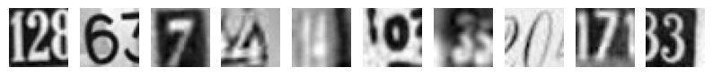

```
label for each of the above image: [2 6 7 4 4 0 3 0 7 3]
```

```python
%matplotlib inline
plt.figure(figsize=(10, 1))
for i in range(10):
    plt.subplot(1, 10, i+1)
    plt.imshow(h5f['X_train'][i], cmap="gray")
    plt.axis('off')
plt.show()
print('label for each of the above image: %s' % (y_train[0:10]))
```

**C. Reshape all the images with appropriate shape update the data in same variable.**

```python
X_train = X_train.reshape(X_train.shape[0], 1024, 1)
X_test = X_test.reshape(X_test.shape[0], 1024, 1)
print('Resized Training set', X_train.shape, y_train.shape)
print('Resized Test set', X_test.shape, y_test.shape)
```

```
Resized Training set (42000, 1024, 1) (42000,)
Resized Test set (18000, 1024, 1) (18000,)
```

**D. Normalise the images i.e. Normalise the pixel values.**

Since the images are in grayscale it can take values from 0-255, we will normalise the data by dividing by 255 so that the input is normalized from 0-255 to 0-1

```python
X_train = X_train / 255.0
X_test = X_test / 255.0

print('Resized Training set', X_train.shape, y_train.shape)
print('Resized Test set', X_test.shape, y_test.shape)
```

```
Resized Training set (42000, 1024, 1) (42000,)
Resized Test set (18000, 1024, 1) (18000,)
```

**E. Transform Labels into format acceptable by Neural Network**

```python
# one hot encode outputs
y_train = to_categorical(y_train)
y_test = to_categorical(y_test)
```

**F. Print total Number of classes in the Dataset**

```python
class_count = y_test.shape[1]
print("The number of classes in this dataset are:",class_count)
```

```
The number of classes in this dataset are: 10
```

#### **3. Model Training & Evaluation using Neural Network**

**A. Design a Neural Network to train a classifier.**

```python
from tensorflow.keras.layers import Dense, Flatten
def nn_model():    # create model
    model = Sequential()
    model.add(Flatten())
    #Hidden Layer
    model.add(Dense(256, activation='relu'))
    model.add(Dense(64, activation='relu'))
    model.add(Dense(64, activation='relu'))
    model.add(Dense(32, activation='relu'))
    #output layer
    model.add(Dense(class_count, activation='softmax'))
    return model

model=nn_model()
```

```python
# Compile model
sgd = optimizers.Adam(learning_rate=1e-3)
### Loss function = Categorical cross entropy
model.compile(loss='categorical_crossentropy',optimizer=sgd, metrics=['accuracy'])
```

**B. Train the classifier using previously designed Architecture (Use best suitable parameters)**

```python
training_history = model.fit(X_train, y_train, validation_data=(    X_test, y_test), epochs=100, batch_size=300, verbose=2)
```

```
140/140 - 5s - loss: 2.2875 - accuracy: 0.1235 - val_loss: 2.2031 - val_accuracy: 0.1568 - 5s/epoch - 36ms/step
140/140 - 3s - loss: 2.0884 - accuracy: 0.2211 - val_loss: 1.9517 - val_accuracy: 0.2816 - 3s/epoch - 22ms/step
140/140 - 2s - loss: 1.8286 - accuracy: 0.3519 - val_loss: 1.6042 - val_accuracy: 0.4626 - 2s/epoch - 17ms/step
140/140 - 2s - loss: 1.5282 - accuracy: 0.4826 - val_loss: 1.4072 - val_accuracy: 0.5271 - 2s/epoch - 17ms/step
140/140 - 2s - loss: 1.3469 - accuracy: 0.5562 - val_loss: 1.2764 - val_accuracy: 0.5874 - 2s/epoch - 17ms/step
140/140 - 3s - loss: 1.2443 - accuracy: 0.5987 - val_loss: 1.2235 - val_accuracy: 0.6000 - 3s/epoch - 24ms/step
140/140 - 3s - loss: 1.1720 - accuracy: 0.6259 - val_loss: 1.1467 - val_accuracy: 0.6351 - 3s/epoch - 20ms/step
140/140 - 2s - loss: 1.1144 - accuracy: 0.6478 - val_loss: 1.0978 - val_accuracy: 0.6554 - 2s/epoch - 16ms/step
140/140 - 3s - loss: 1.0726 - accuracy: 0.6634 - val_loss: 1.0553 - val_accuracy: 0.6671 - 3s/epoch - 18ms/step
140/140 - 2s - loss: 1.0259 - accuracy: 0.6811 - val_loss: 1.0242 - val_accuracy: 0.6797 - 2s/epoch - 16ms/step
140/140 - 3s - loss: 0.9874 - accuracy: 0.6947 - val_loss: 0.9695 - val_accuracy: 0.7010 - 3s/epoch - 22ms/step
140/140 - 3s - loss: 0.9366 - accuracy: 0.7123 - val_loss: 0.9323 - val_accuracy: 0.7165 - 3s/epoch - 23ms/step
140/140 - 3s - loss: 0.9092 - accuracy: 0.7200 - val_loss: 0.9796 - val_accuracy: 0.6963 - 3s/epoch - 18ms/step
140/140 - 2s - loss: 0.8892 - accuracy: 0.7256 - val_loss: 0.9040 - val_accuracy: 0.7210 - 2s/epoch - 17ms/step
140/140 - 2s - loss: 0.8737 - accuracy: 0.7300 - val_loss: 0.9432 - val_accuracy: 0.7096 - 2s/epoch - 17ms/step
140/140 - 3s - loss: 0.8523 - accuracy: 0.7373 - val_loss: 0.8722 - val_accuracy: 0.7313 - 3s/epoch - 21ms/step
140/140 - 3s - loss: 0.8361 - accuracy: 0.7418 - val_loss: 0.8745 - val_accuracy: 0.7292 - 3s/epoch - 23ms/step
140/140 - 3s - loss: 0.8186 - accuracy: 0.7482 - val_loss: 0.9054 - val_accuracy: 0.7248 - 3s/epoch - 18ms/step
140/140 - 3s - loss: 0.8083 - accuracy: 0.7505 - val_loss: 0.8320 - val_accuracy: 0.7454 - 3s/epoch - 18ms/step
140/140 - 2s - loss: 0.7780 - accuracy: 0.7602 - val_loss: 0.8348 - val_accuracy: 0.7461 - 2s/epoch - 17ms/step
140/140 - 3s - loss: 0.7664 - accuracy: 0.7643 - val_loss: 0.8075 - val_accuracy: 0.7566 - 3s/epoch - 21ms/step
140/140 - 3s - loss: 0.7556 - accuracy: 0.7657 - val_loss: 0.7993 - val_accuracy: 0.7581 - 3s/epoch - 24ms/step
140/140 - 2s - loss: 0.7415 - accuracy: 0.7723 - val_loss: 0.8328 - val_accuracy: 0.7464 - 2s/epoch - 17ms/step
140/140 - 3s - loss: 0.7344 - accuracy: 0.7732 - val_loss: 0.8330 - val_accuracy: 0.7470 - 3s/epoch - 19ms/step
140/140 - 2s - loss: 0.7220 - accuracy: 0.7774 - val_loss: 0.7736 - val_accuracy: 0.7659 - 2s/epoch - 17ms/step
140/140 - 3s - loss: 0.7051 - accuracy: 0.7830 - val_loss: 0.8011 - val_accuracy: 0.7577 - 3s/epoch - 20ms/step
140/140 - 3s - loss: 0.6939 - accuracy: 0.7856 - val_loss: 0.7635 - val_accuracy: 0.7707 - 3s/epoch - 22ms/step
140/140 - 3s - loss: 0.6746 - accuracy: 0.7927 - val_loss: 0.7493 - val_accuracy: 0.7770 - 3s/epoch - 18ms/step
140/140 - 2s - loss: 0.6620 - accuracy: 0.7956 - val_loss: 0.7521 - val_accuracy: 0.7753 - 2s/epoch - 17ms/step
140/140 - 3s - loss: 0.6578 - accuracy: 0.7990 - val_loss: 0.7787 - val_accuracy: 0.7699 - 3s/epoch - 18ms/step
140/140 - 3s - loss: 0.6453 - accuracy: 0.8004 - val_loss: 0.7095 - val_accuracy: 0.7902 - 3s/epoch - 19ms/step
140/140 - 4s - loss: 0.6448 - accuracy: 0.8016 - val_loss: 0.7469 - val_accuracy: 0.7767 - 4s/epoch - 26ms/step
140/140 - 3s - loss: 0.6415 - accuracy: 0.8024 - val_loss: 0.7223 - val_accuracy: 0.7841 - 3s/epoch - 19ms/step
140/140 - 3s - loss: 0.6365 - accuracy: 0.8055 - val_loss: 0.7187 - val_accuracy: 0.7822 - 3s/epoch - 19ms/step
140/140 - 2s - loss: 0.6264 - accuracy: 0.8073 - val_loss: 0.7140 - val_accuracy: 0.7858 - 2s/epoch - 17ms/step
140/140 - 3s - loss: 0.6181 - accuracy: 0.8100 - val_loss: 0.7441 - val_accuracy: 0.7808 - 3s/epoch - 20ms/step
140/140 - 4s - loss: 0.6097 - accuracy: 0.8121 - val_loss: 0.7401 - val_accuracy: 0.7814 - 4s/epoch - 25ms/step
140/140 - 2s - loss: 0.6003 - accuracy: 0.8144 - val_loss: 0.6988 - val_accuracy: 0.7962 - 2s/epoch - 17ms/step
140/140 - 3s - loss: 0.5964 - accuracy: 0.8171 - val_loss: 0.7198 - val_accuracy: 0.7858 - 3s/epoch - 19ms/step
140/140 - 3s - loss: 0.5917 - accuracy: 0.8183 - val_loss: 0.6968 - val_accuracy: 0.7957 - 3s/epoch - 18ms/step
```

[output cut: 45 more lines]

```
140/140 - 3s - loss: 0.4424 - accuracy: 0.8594 - val_loss: 0.6704 - val_accuracy: 0.8062 - 3s/epoch - 18ms/step
140/140 - 3s - loss: 0.4352 - accuracy: 0.8641 - val_loss: 0.6680 - val_accuracy: 0.8109 - 3s/epoch - 19ms/step
140/140 - 3s - loss: 0.4409 - accuracy: 0.8630 - val_loss: 0.6763 - val_accuracy: 0.8093 - 3s/epoch - 25ms/step
140/140 - 2s - loss: 0.4374 - accuracy: 0.8620 - val_loss: 0.6672 - val_accuracy: 0.8131 - 2s/epoch - 16ms/step
140/140 - 3s - loss: 0.4365 - accuracy: 0.8624 - val_loss: 0.6538 - val_accuracy: 0.8164 - 3s/epoch - 18ms/step
140/140 - 2s - loss: 0.4387 - accuracy: 0.8611 - val_loss: 0.6486 - val_accuracy: 0.8137 - 2s/epoch - 16ms/step
140/140 - 3s - loss: 0.4380 - accuracy: 0.8617 - val_loss: 0.6524 - val_accuracy: 0.8166 - 3s/epoch - 19ms/step
140/140 - 4s - loss: 0.4247 - accuracy: 0.8663 - val_loss: 0.6952 - val_accuracy: 0.8076 - 4s/epoch - 26ms/step
140/140 - 2s - loss: 0.4370 - accuracy: 0.8629 - val_loss: 0.6829 - val_accuracy: 0.8036 - 2s/epoch - 16ms/step
140/140 - 2s - loss: 0.4344 - accuracy: 0.8621 - val_loss: 0.6440 - val_accuracy: 0.8192 - 2s/epoch - 16ms/step
140/140 - 3s - loss: 0.4260 - accuracy: 0.8668 - val_loss: 0.6643 - val_accuracy: 0.8122 - 3s/epoch - 18ms/step
140/140 - 3s - loss: 0.4287 - accuracy: 0.8641 - val_loss: 0.6649 - val_accuracy: 0.8124 - 3s/epoch - 18ms/step
140/140 - 4s - loss: 0.4326 - accuracy: 0.8622 - val_loss: 0.6407 - val_accuracy: 0.8177 - 4s/epoch - 25ms/step
140/140 - 2s - loss: 0.4159 - accuracy: 0.8688 - val_loss: 0.6436 - val_accuracy: 0.8195 - 2s/epoch - 16ms/step
140/140 - 3s - loss: 0.4162 - accuracy: 0.8686 - val_loss: 0.6660 - val_accuracy: 0.8119 - 3s/epoch - 18ms/step
```

**C. Evaluate performance of the model with appropriate metrics.**

```python
scores = model.evaluate(X_test, y_test, verbose=0)
print("Loss:", scores[0])
print("Accuracy:", scores[1])
```

```
Loss: 0.6660038828849792
Accuracy: 0.8118888735771179
```

D. Plot the training loss, validation loss vs number of epochs and training accuracy, validation accuracy vs number of epochs plot and write your observations on the same.

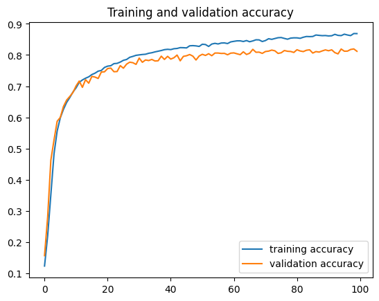

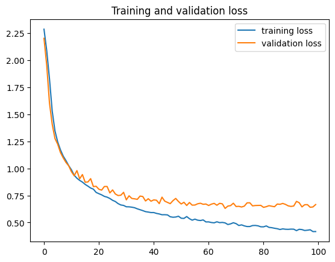

```python
accuracy      = training_history.history['accuracy']
val_accuracy  = training_history.history['val_accuracy']
loss     = training_history.history['loss']
val_loss = training_history.history['val_loss']

epochs   = range(len(accuracy)) # Get number of epochs

plt.plot  ( epochs, accuracy, label = 'training accuracy' )
plt.plot  ( epochs, val_accuracy, label = 'validation accuracy' )
plt.title ('Training and validation accuracy')
plt.legend(loc = 'lower right')
plt.figure()

plt.plot  ( epochs, loss, label = 'training loss' )
plt.plot  ( epochs, val_loss, label = 'validation loss' )
plt.legend(loc = 'upper right')
plt.title ('Training and validation loss'   )
```

**Observations:**

- The target variable has 10 Classes which indicates values from 0-9.
- The Neural network built has 4 dense hidden layers with 32,64,64,256 units and RELU as Activation function.
- The Neural network was able to achive and accuracy of around 81.20% of accuracy on Validateion data.
- There seems to be some degree of overfitting since there is around 20% increase in loss from training which is around 44% to Validation loss of aroun 68%.